March 4, 2020

## Preparing R

Install and load packages

```r
# if (!requireNamespace("BiocManager", quietly = TRUE))
#     install.packages("BiocManager")
#
# BiocManager::install("edgeR")

library("tidyverse")
library("here")
library("edgeR")
library("pheatmap")
library("ggthemes")
```

This should install readr, tidyr, dplyr, purr, stringr, ggplot2, tibble, and forcats.

## Set working directory

```r
# no need
getwd() #just to confirm
```

```
## [1] "/Users/jagannas/Downloads/molb7910-master/5-class5"
```

## Differential gene expression using edgeR

## Introduction

There are a number of steps in conducting differential gene expression analysis using RNA-seq data. Here, we assume that you have already mapped and counted the reads from an RNA-seq experiment (i. e. fastq data has been mapped to a reference genome and reads that map to a certain gene have been counted using a program such as STAR). Once you have the count data, we will generate matrix containing sample names as column ids and gene names as row ids. This matrix can then be input into edgeR to generate log2 fold change values for each gene along with a p-value and fdr. The code we will use to accomplish this is simple, but does a LOT to your data behind the scenes.

## Introduction

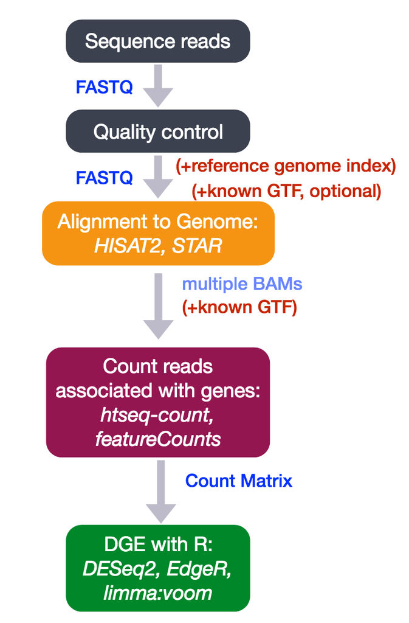

## Let’s get started!

## Importing data

```r
data_gene_level <- read_csv("data/input/data_gene_level.csv")
data_gene_level <- data_gene_level  %>% select(-X1)
```

## Prepare data

```r
# make long data wide


data_gene_level_wide <- data_gene_level %>%
                      # step 1 - unite time, replicate, and type into one column
                      unite(condition, type, time, replicate, sep = "_") %>%
                      # step 2 - spread -> pivot_wider (the new spread)
                      pivot_wider(names_from = condition, values_from = count) %>%
                      # remove rows with no ensembl gene ids
                      filter(!is.na(ensembl_gene_id))

# arrange columns by proper time point
data_gene_level_wide <- data_gene_level_wide[, c(1:5, 9:14, 6:8)]
```

For edgeR to work, we need the count data to be in a matrix with gene names as row names and sample names as column names. Tibbles (`tbl_df`) do not allow a variable to be contained in a row name. Therefore, they don’t allow row names at all. Hence, we need to convert the data_gene_level_wide tibble to a data.frame.

```r
geneExpr <- data.frame(data_gene_level_wide) #tbl_df to data.frame
row.names(geneExpr) <- geneExpr$ensembl_gene_id # This is where we move the gene id information into row name
x <- geneExpr[, c(3:14)] # then, we get rid of the column containing non-numeric information. Thus, generating out matrix of count data.
```

## edgeR analysis

## 1. Subsetting the data:

if you want to only consider a subset of conditions for fold-change calculations

```r
# Examples
# keeping 0h and 14h samples only
x1 <- x[, c(1:3, 10:12)]
# comparing 0h and 4h samples
x2 <- x[, c(1:6)]
```

## 2. Define sample grouping

```r
time <- factor(c("hour00", "hour00", "hour00",
                  "hour14", "hour14", "hour14"))
```

#Note: If you made more than one sets, you need to define their grouping individually as group1, group2, etc.

## 3. Generate a DGE list

```r
d <- DGEList(counts=x1, group = time)
```

## 4. Filter genes with low counts & normalize

(require >1 cpm in at least 1/2 of the samples)

```r
# identify the rows to keep that have cpm() > 1
keep <- rowSums(cpm(d)>1) >= 3
# remove the rows that don't have sufficient cpm
d <- d[keep, , keep.lib.sizes=FALSE]
```

## 5. Calculate normalization factors to scale the raw library sizes.

edgeR normalizes the genes counts using the method TMM (trimmed means of m values). TMM removes the extremely lowly and highly expressed genes and also those genes that are very different across samples. It then compares the total counts for this subset of genes between the two samples to get the scaling factor. *Never* give edgeR pre-normalized counts.

```r
d <- calcNormFactors(d, method = "TMM")
```

## Did the normalization work? Let’s check

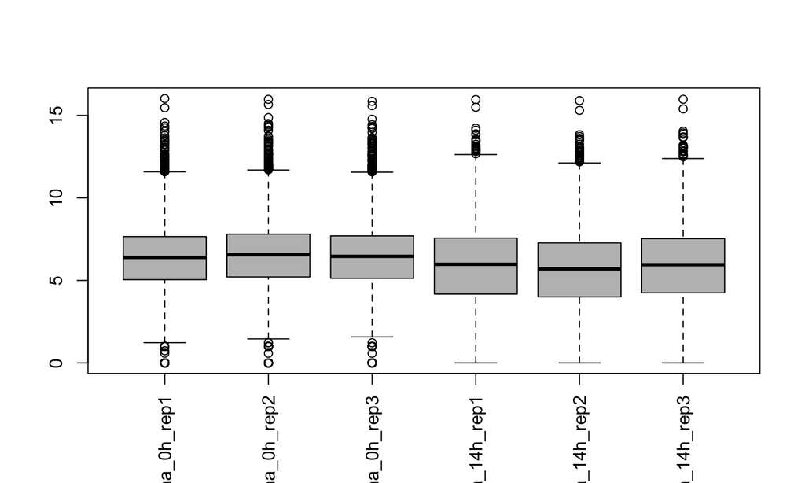

```r
counts <- d$counts
pseudoCounts <- log2(counts + 1)
boxplot(pseudoCounts, col="gray", las=3)
```

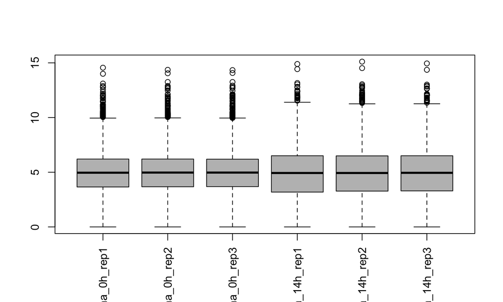

```r
normCounts <- cpm(d)
pseudoNormCounts <- log2(normCounts + 1)
boxplot(pseudoNormCounts, col="gray", las=3)
```

## 6. create a model matrix to allow linear modeling

```r
design <- model.matrix(~time)
```

## 7. estimate dispersion

```r
d <- estimateDisp(d, design)
class(d)
```

```
## [1] "DGEList"
## attr(,"package")
## [1] "edgeR"
```

## What is dispersion?

- Dispersion measures the variability of the abundance of a gene within replicates.
- Biological CV (BCV) is the sqrt of dispersion

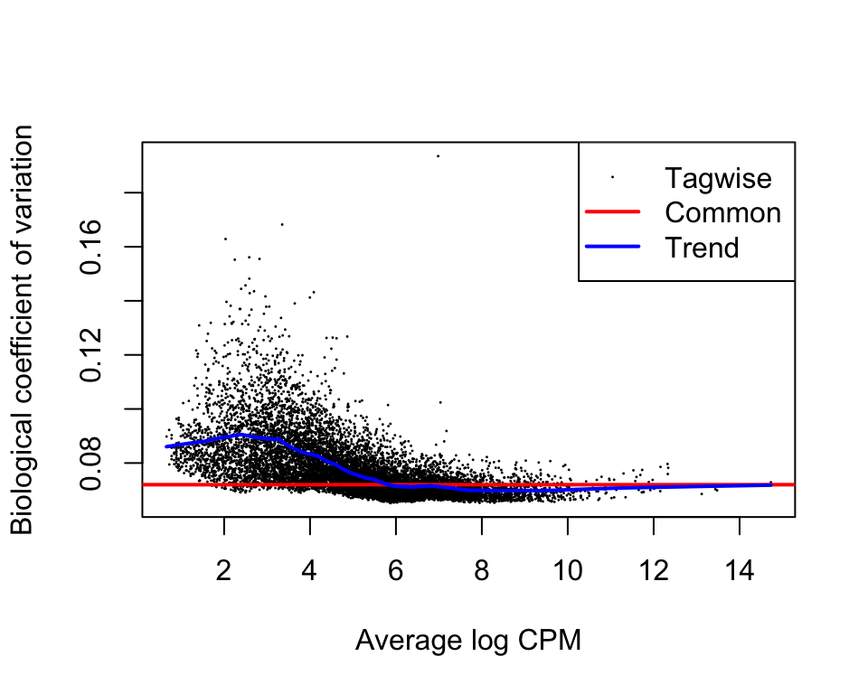

```r
plotBCV(d)
```

## 8. Fit a generalized linear model

For RNA-seq count data, this is a negative binomial generalized log-linear model. More info in the reference and also [here](https://www.theanalysisfactor.com/count-vs-continuous-variables-differences-under-the-hood/)

```r
d1 <- glmFit(d, design)
class(d1)
```

```
## [1] "DGEGLM"
## attr(,"package")
## [1] "edgeR"
```

## 9. Conduct Tagwise likelihood ratio tests for DGEGLM

```r
d2 <- glmLRT(d1, coef=2)
class(d2)
```

```
## [1] "DGELRT"
## attr(,"package")
## [1] "edgeR"
```

## 10. Extract differentially expressed genes

Extract the most differentially expressed genes (or sequence tags) from a test object, ranked either by p-value or by absolute log-fold-change.

```r
DUX4_14h <- topTags(d2, n=10610)
#DUX4 <- topTags(d2, n = Inf)
#DUX4 <- topTags(d2, n=500)
```

## Data clean up and export

```r
foldchange_14h <- cbind(ensembl_gene_id = row.names(DUX4_14h$table),
                    DUX4_14h$table)
foldchange_14h <- left_join(data_gene_level_wide, foldchange_14h,
                        by = "ensembl_gene_id")
foldchange_14h <- unique(foldchange_14h)
write.csv(foldchange_14h, file = "data/output/foldchange_14h.csv")
```

## M-A plot

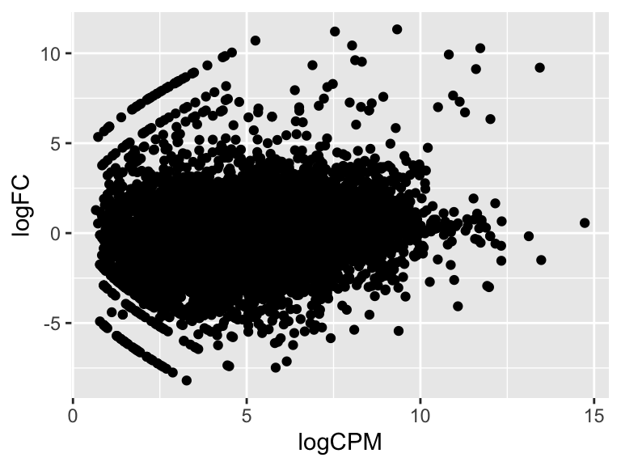

```r
ggplot(foldchange_14h, aes(x = logCPM, y = logFC)) +
  geom_point()
```

## Volcano plot

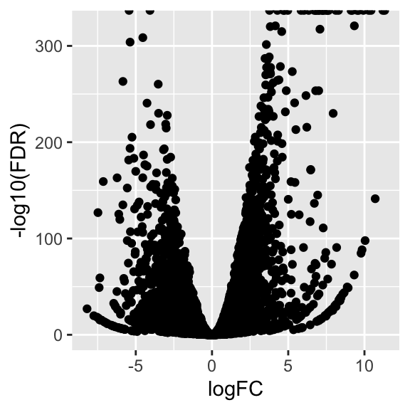

```r
ggplot(foldchange_14h, aes(x = logFC, y = -log10(FDR))) +
  geom_point()
```

#### References

Youtube video on edgeR: https://www.youtube.com/watch?v=5tGCBW3_0IA  
edgeR tutorial 1: https://web.stanford.edu/class/bios221/labs/rnaseq/lab_4_rnaseq.html edgeR tutorial 2: https://gist.github.com/jdblischak/11384914 GLM for RNA-seq data: https://bioramble.wordpress.com/2016/01/30/why-sequencing-data-is-modeled-as-negative-binomial/